# Описание проекта

Были **уволены** 1128 человек *(28%)* из 4000.

```
Датафрейм test_target_quit_df:
```

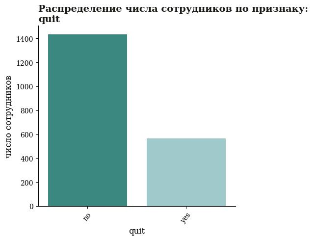

```python
show_bar_graphs(test_target_quit_df, 'test_target_quit_df')
# вызов функции show_bar_graphs для test_target_quit_df
```

Теперь составим портрет «**уволившегося** сотрудника» и сравним с теми, кто остался в компании.

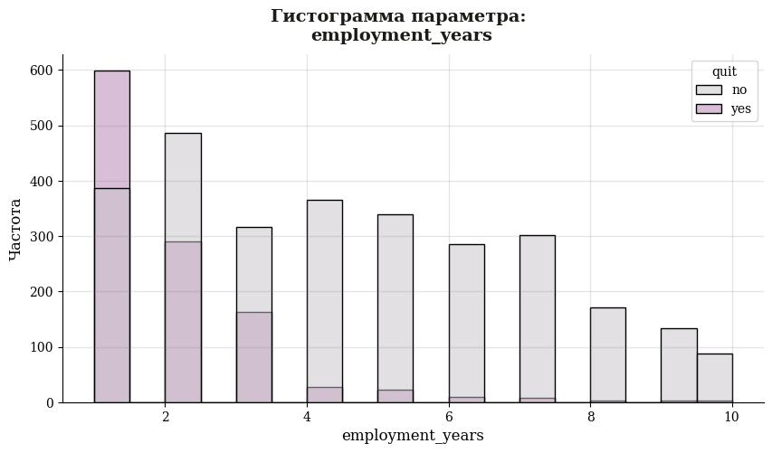

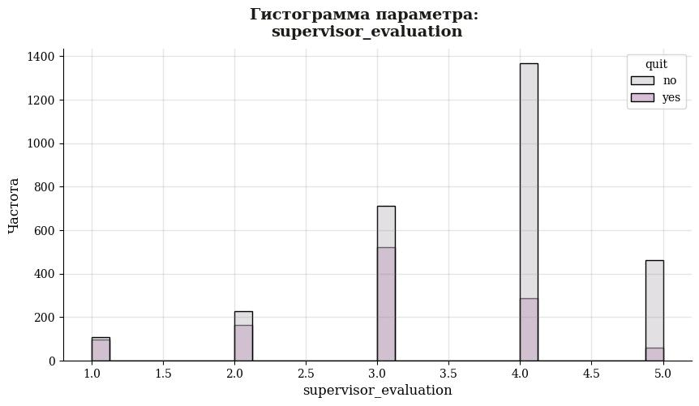

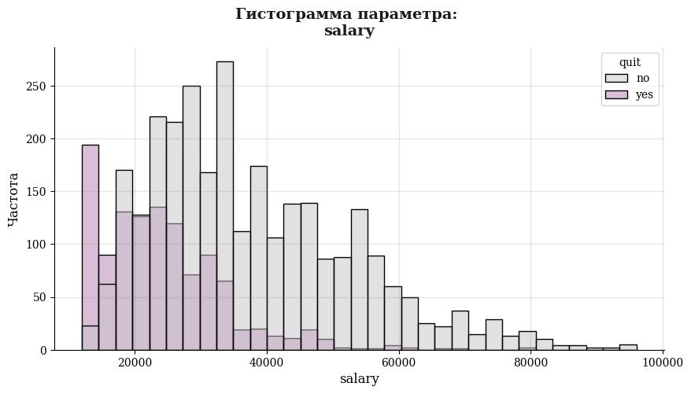

```python
for column in list(train_quit_df.select_dtypes(include=[float, int]).columns)[1:]:

        fig = plt.figure(figsize=(10, 5))
        ax1 = fig.add_subplot(1, 1, 1)
        # создание сетки из подграфиков
        ax1.grid(which='major', linewidth=1, color='gray', alpha=0.2)
        # изменение параметров сетки
        ax1.spines['top'].set_visible(False)
        ax1.spines['right'].set_visible(False)
        # удаление линий осей

        fig.suptitle(f'''Гистограмма параметра: \n{column}''',
                     fontsize=14,
                     fontweight='demi',
                     color='#1B1B17')
        # добавление заголовка

        sns.histplot(train_quit_df,
                     x=column,
                     hue='quit',
                     palette=['#C8C3C9', '#B47EB2'],
                     ax=ax1
                    )
        # создание гистограммы

        plt.xlabel(column, fontsize=12)
        plt.ylabel('Частота', fontsize=12)
        # подпись оси x

        plt.show()
        # вывод графика
```

[figure not shown]

[figure not shown]

[figure not shown]

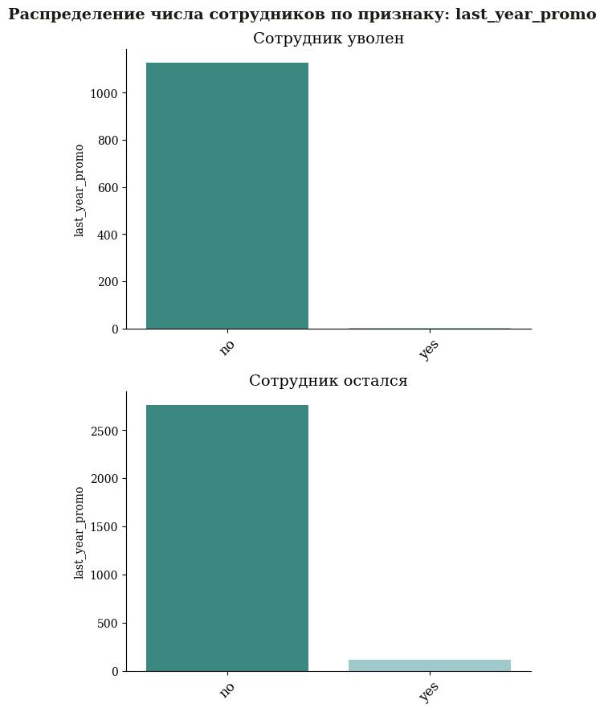

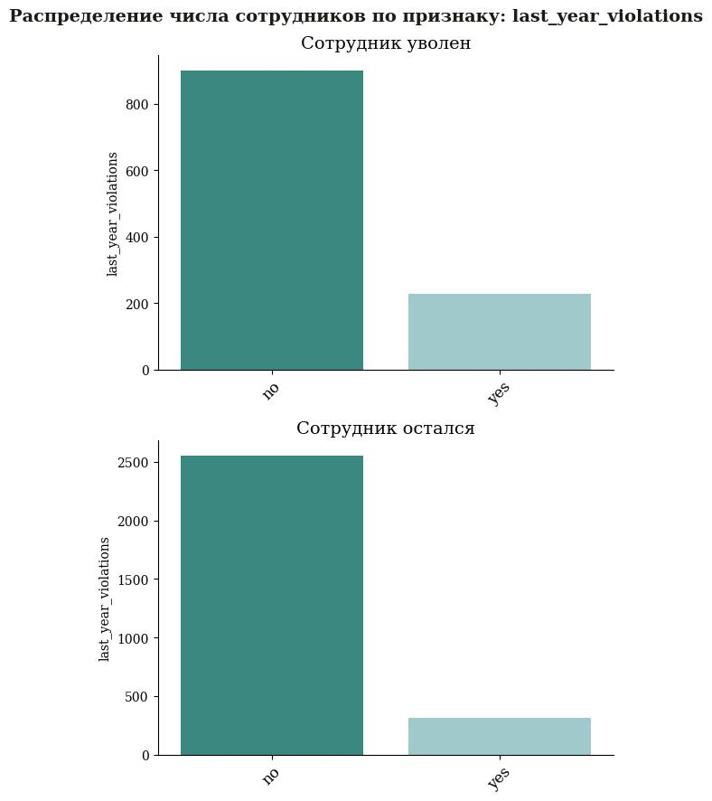

```python
for column in list(train_quit_df.select_dtypes(include=[object]).columns)[:5]:

        if train_quit_df[column].nunique() < 4:
            fig = plt.figure(figsize=(6, 9))
        else:
            fig = plt.figure(figsize=(9, 10))

        ax1 = fig.add_subplot(2, 1, 1)
        ax2 = fig.add_subplot(2, 1, 2)
        # создание сетки из подграфиков
        ax1.spines['top'].set_visible(False)
        ax1.spines['right'].set_visible(False)
        ax2.spines['top'].set_visible(False)
        ax2.spines['right'].set_visible(False)
        # удаление линий осей

        ax1.set_title('Сотрудник уволен', fontsize=14)
        ax2.set_title('Сотрудник остался', fontsize=14)
        # добавление подзаголовков

        fig.suptitle(f'''Распределение числа сотрудников по признаку: {column}''',
                     fontsize=14,
                     fontweight='demi',
                     color='#1B1B17')
        # добавление заголовка

        sns.barplot((train_quit_df
                     .query('quit == "yes"')[column]
                     .value_counts()
                     .reset_index()
                    ),
                    x='index',
                    y=column,
                    palette=['#2E958C', '#99D0D3', '#FCE0D5', '#C8C3C9', '#B47EB2'],
                    ax=ax1
                    )

        sns.barplot((train_quit_df
                     .query('quit == "no"')[column]
                     .value_counts()
                     .reset_index()
                    ),
                    x='index',
                    y=column,
                    palette=['#2E958C', '#99D0D3', '#FCE0D5', '#C8C3C9', '#B47EB2'],
                    ax=ax2
                    )
        # создание столбчатых диаграмм

        ax1.set_xticklabels(train_quit_df[column].unique(), rotation=45, fontsize=12)
        ax2.set_xticklabels(train_quit_df[column].unique(), rotation=45, fontsize=12)
        ax1.set_xlabel(None)
        ax2.set_xlabel(None)
        # подписи осей

        plt.tight_layout()
        plt.show()
        # вывод графиков
```

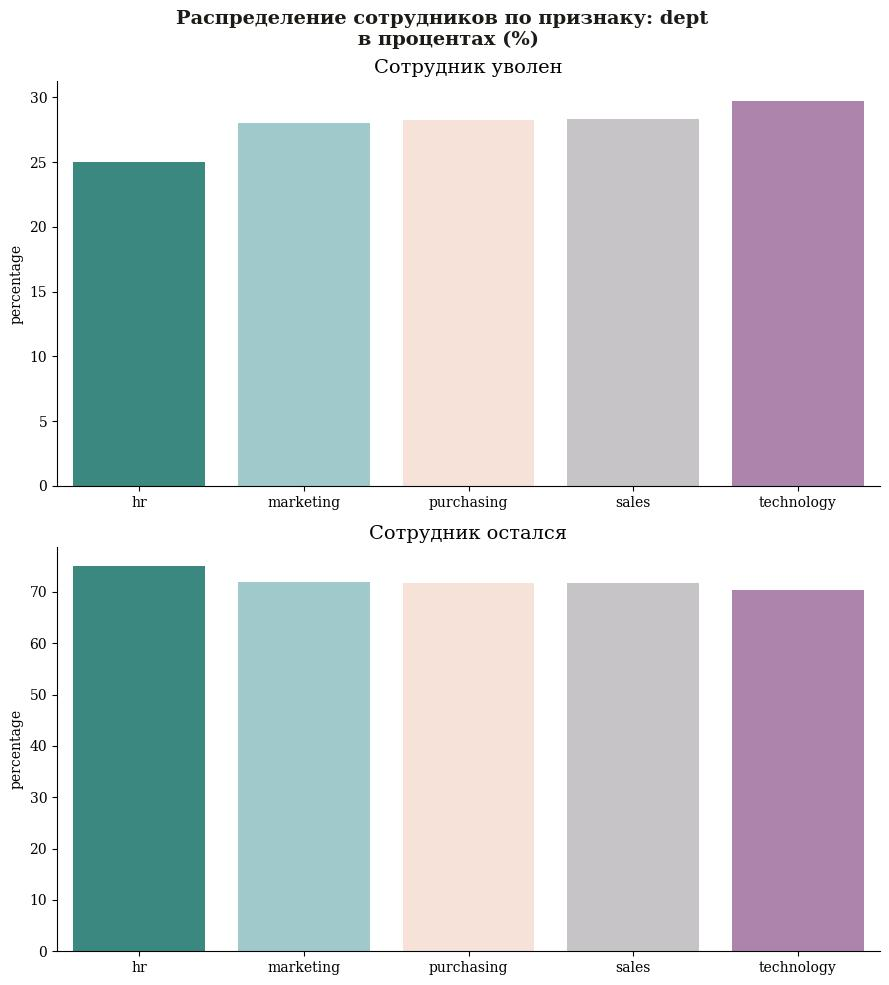

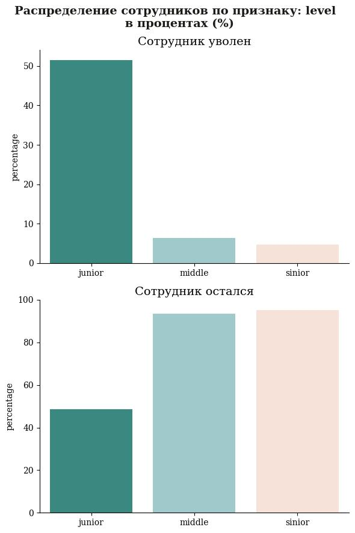

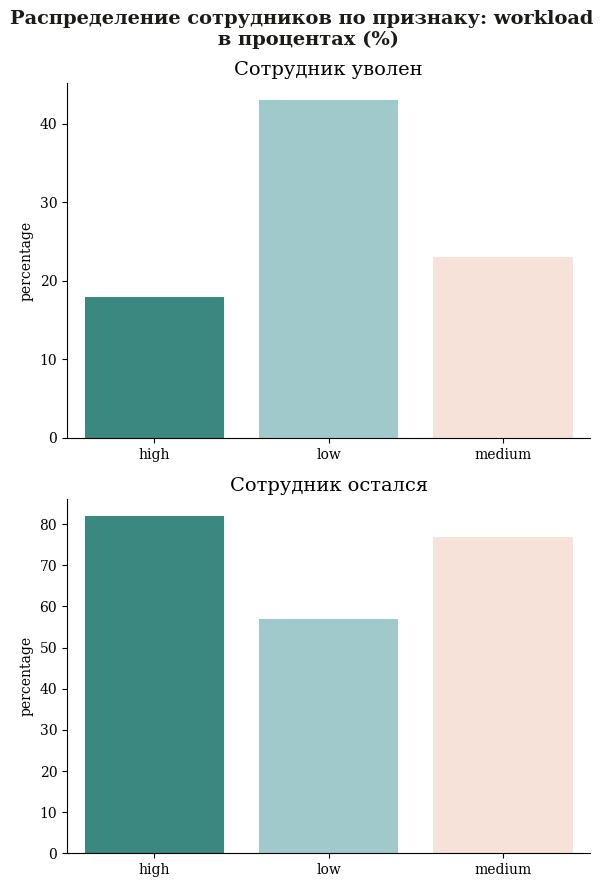

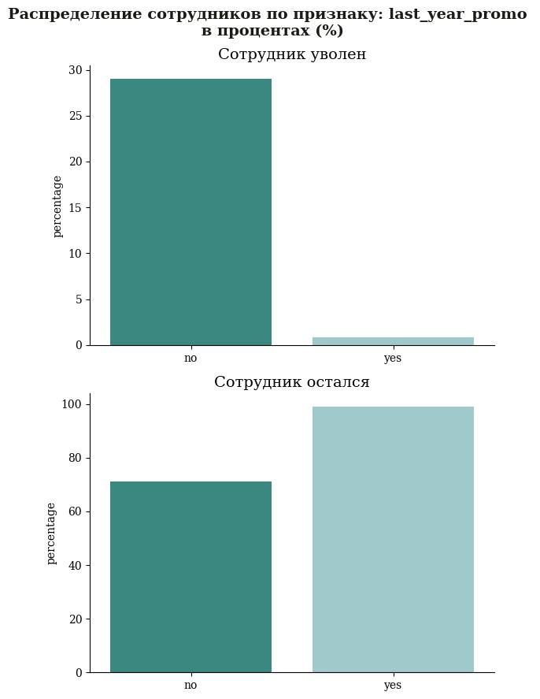

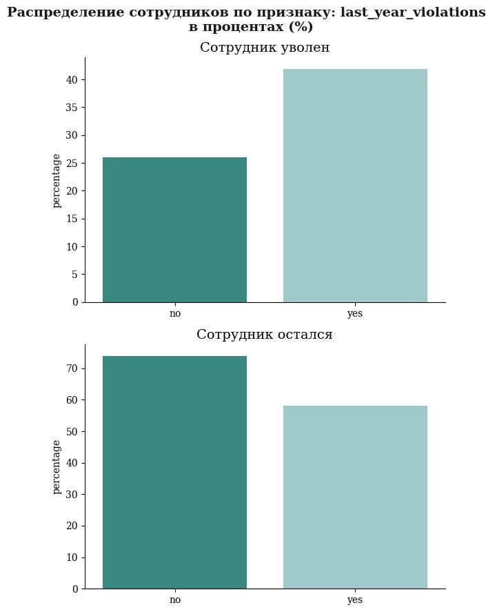

```python
for column in list(train_quit_df.select_dtypes(include=[object]).columns)[:5]:

        train_quit_df_yes = (train_quit_df.query('quit == "yes"').groupby(column).size()/train_quit_df.groupby(column).size()).reset_index()
        train_quit_df_yes.columns = [column, 'percentage']
        train_quit_df_yes['percentage'] = train_quit_df_yes['percentage'].apply(lambda x: round((x * 100), 2))

        train_quit_df_no = (train_quit_df.query('quit == "no"').groupby(column).size()/train_quit_df.groupby(column).size()).reset_index()
        train_quit_df_no.columns = [column, 'percentage']
        train_quit_df_no['percentage'] = train_quit_df_no['percentage'].apply(lambda x: round((x * 100), 2))
        # создание сводных таблиц

        if train_quit_df[column].nunique() < 4:
            fig = plt.figure(figsize=(6, 9))
        else:
            fig = plt.figure(figsize=(9, 10))

        ax1 = fig.add_subplot(2, 1, 1)
        ax2 = fig.add_subplot(2, 1, 2)
        # создание сетки из подграфиков
        ax1.spines['top'].set_visible(False)
        ax1.spines['right'].set_visible(False)
        ax2.spines['top'].set_visible(False)
        ax2.spines['right'].set_visible(False)
        # удаление линий осей

        ax1.set_title('Сотрудник уволен', fontsize=14)
        ax2.set_title('Сотрудник остался', fontsize=14)
        # добавление подзаголовков

        fig.suptitle(f'''Распределение сотрудников по признаку: {column} \n в процентах (%)''',
                     fontsize=14,
                     fontweight='demi',
                     color='#1B1B17')
        # добавление заголовка

        sns.barplot(train_quit_df_yes,
                    x=column,
                    y='percentage',
                    palette=['#2E958C', '#99D0D3', '#FCE0D5', '#C8C3C9', '#B47EB2'],
                    ax=ax1
                    )

        sns.barplot(train_quit_df_no,
                    x=column,
                    y='percentage',
                    palette=['#2E958C', '#99D0D3', '#FCE0D5', '#C8C3C9', '#B47EB2'],
                    ax=ax2
                    )
        # создание столбчатых диаграмм

        ax1.set_xlabel(None)
        ax2.set_xlabel(None)
        # подписи осей

        plt.tight_layout()
        plt.show()
        # вывод графиков
```

Уволенные сотрудники в среднем проработали в компании меньше лет, чем оставшиеся. Большинство - всего **1-2 года**. Их медианная оценка качества работы от начальства **(3)** на балл меньше оценки оставшихся сотрудников. Средняя зарплата уволенных также была на порядок меньше - **22 800**.

Среди уволенных по *отделам* самый большой процент **29.7%** наблюдается у технологического. На последнем месте hr отдел. Там было уволено 25%. Уволенных *джунов* - **51%**, а 6.4 и 4.8% приходится на мидлов и сеньоров соответственно. Интересно, что по уровню загруженности самая большая доля уволенных **43%** у *мало загруженных*. **(30%)** из тех, кто *не получал повышения за прошлый год*, были уволены и всего 0.9% из тех, кто повышение получил. У *нарушивших трудовой договор* сотрудников доля уволенных составляет **42%**, у добросовестных - 26%.

Добавим признак `job_satisfaction_rate` в нашу тренировочную выборку train_quit_df. Визуализируем распределения оценок уровня удовлетворённости сотрудника работой для ушедших и оставшихся сотрудников.

```python
train_quit_df['job_satisfaction_rate'] = best_model.predict(train_quit_df.drop(['id', 'quit'], axis=1))
# предсказываем уровень удовлетворённости с помощью лучшей модели
```

```python
train_quit_df.head()
# вывод первых 5 строк
```

|  | id | dept | level | workload | employment_years | last_year_promo | last_year_violations | supervisor_evaluation | salary | quit | job_satisfaction_rate |
| --- | --- | --- | --- | --- | --- | --- | --- | --- | --- | --- | --- |
| 0 | 723290 | sales | middle | high | 2 | no | no | 4 | 54000 | no | 0.660000 |
| 1 | 814010 | sales | junior | medium | 2 | no | no | 4 | 27600 | no | 0.853529 |
| 2 | 155091 | purchasing | middle | medium | 5 | no | no | 1 | 37200 | no | 0.364091 |
| 3 | 257132 | sales | junior | medium | 2 | no | yes | 3 | 24000 | yes | 0.380000 |
| 4 | 910140 | marketing | junior | medium | 2 | no | no | 5 | 25200 | no | 0.690000 |

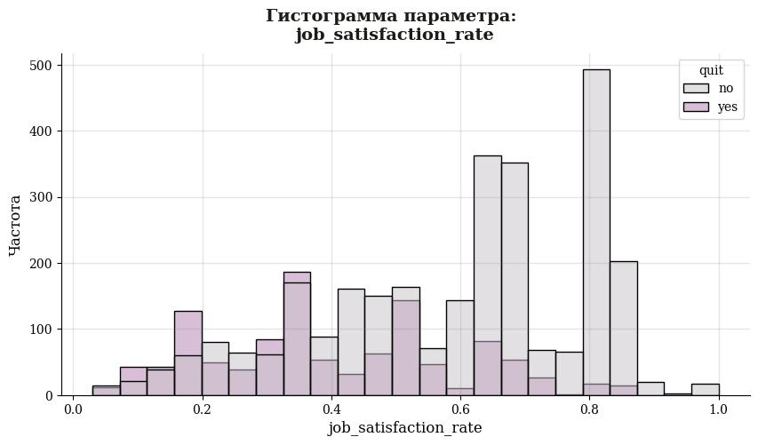

```python
fig = plt.figure(figsize=(10, 5))
ax1 = fig.add_subplot(1, 1, 1)
# создание сетки из подграфиков
ax1.grid(which='major', linewidth=1, color='gray', alpha=0.2)
# изменение параметров сетки
ax1.spines['top'].set_visible(False)
ax1.spines['right'].set_visible(False)
# удаление линий осей

fig.suptitle(f'''Гистограмма параметра: \n{'job_satisfaction_rate'}''',
                     fontsize=14,
                     fontweight='demi',
                     color='#1B1B17')
# добавление заголовка

sns.histplot(train_quit_df,
                     x='job_satisfaction_rate',
                     hue='quit',
                     palette=['#C8C3C9', '#B47EB2'],
                     ax=ax1
            )
# создание гистограммы

plt.xlabel('job_satisfaction_rate', fontsize=12)
plt.ylabel('Частота', fontsize=12)
# подпись оси x

plt.show()
# вывод графика
```

```python
print('Cредний коэффициент удовлетворенности работой ушедших сотрудников:', round(train_quit_df.query("quit == 'yes'")['job_satisfaction_rate'].mean(), 3))
print('Cредний коэффициент удовлетворенности работой оставшихся сотрудников:', round(train_quit_df.query("quit == 'no'")['job_satisfaction_rate'].mean(), 3))
```

```
Cредний коэффициент удовлетворенности работой ушедших сотрудников: 0.399
Cредний коэффициент удовлетворенности работой оставшихся сотрудников: 0.592
```

## Задача 2: Корреляционный анализ

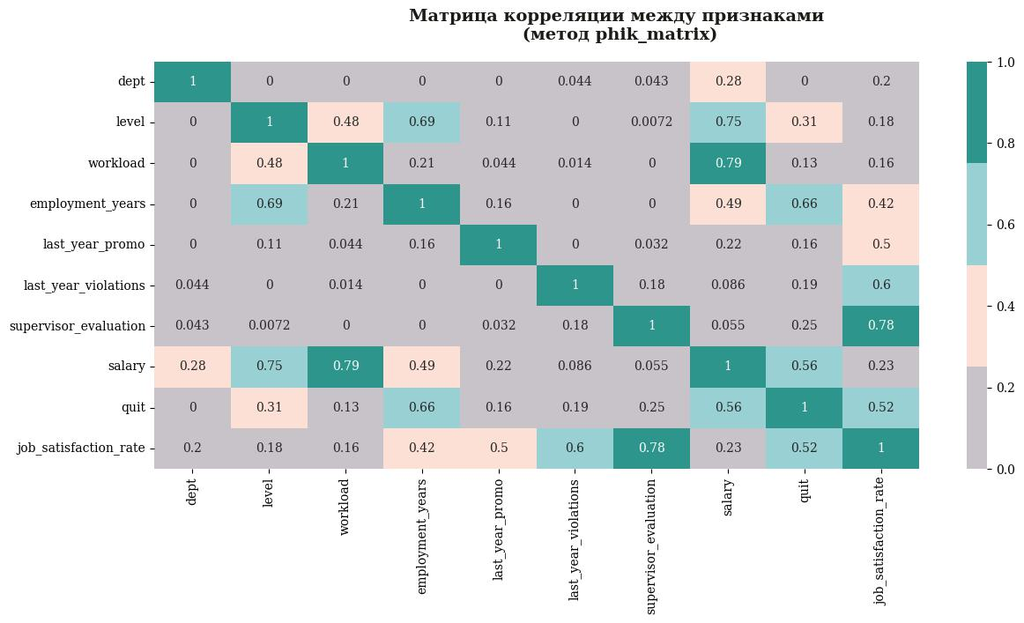

```python
fig = plt.figure(figsize=(14, 6))
fig.suptitle(f'Матрица корреляции между признаками\n (метод phik_matrix)', fontsize=14, fontweight='demi', color='#1B1B17')
ax1 = fig.add_subplot(1, 1, 1)
sns.heatmap(train_quit_df.drop('id', axis=1).phik_matrix(interval_cols=['employment_years', 'supervisor_evaluation', 'salary', 'job_satisfaction_rate']), ax=ax1, cmap=['#C8C3C9', '#FCE0D5', '#99D0D3', '#2E958C'], annot=True)

plt.show()
# построение тепловой карты корреляций с помощью метода phik_matrix()
```

Из всех входных признаков больше всего коррелируют между собой переменные `salary` и `workload` (коэффициент phik **0.79**), `salary` и `level` (коэффициент phik **0.75**), а также `job_satisfaction_rate` и `supervisor_evaluation` (коэффициент phik **0.78**). В данном случае мы не можем говорить о возможном наличии мультиколлинеарности, так как коэффициенты корреляций меньше 0.85.

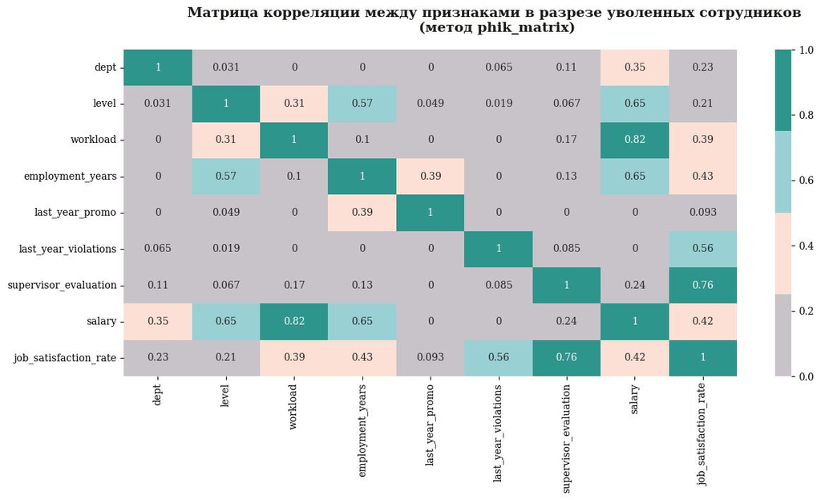

```python
fig = plt.figure(figsize=(14, 6))
fig.suptitle(f'Матрица корреляции между признаками в разрезе уволенных сотрудников\n (метод phik_matrix)', fontsize=14, fontweight='demi', color='#1B1B17')
ax1 = fig.add_subplot(1, 1, 1)
sns.heatmap(train_quit_df.query("quit == 'yes'").drop('id', axis=1).phik_matrix(interval_cols=['employment_years', 'supervisor_evaluation', 'salary', 'job_satisfaction_rate']), ax=ax1, cmap=['#C8C3C9', '#FCE0D5', '#99D0D3', '#2E958C'], annot=True)

plt.show()
# построение тепловой карты корреляций с помощью метода phik_matrix()
```

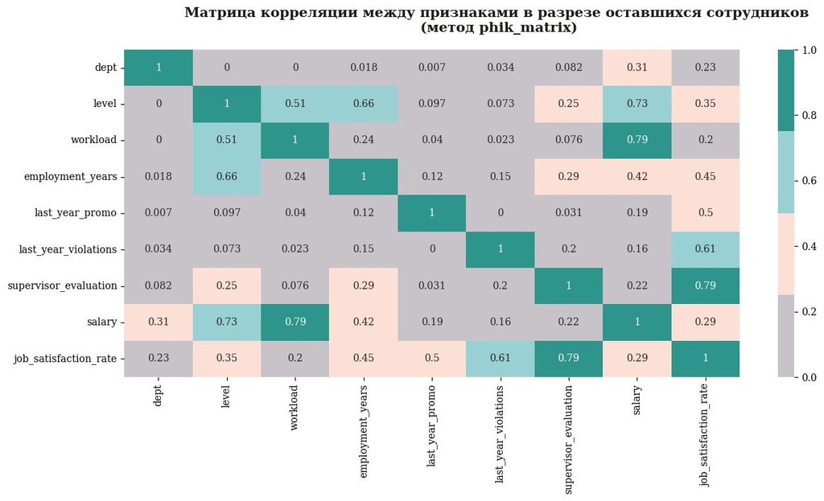

```python
fig = plt.figure(figsize=(14, 6))
fig.suptitle(f'Матрица корреляции между признаками в разрезе оставшихся сотрудников\n (метод phik_matrix)', fontsize=14, fontweight='demi', color='#1B1B17')
ax1 = fig.add_subplot(1, 1, 1)
sns.heatmap(train_quit_df.query("quit == 'no'").drop('id', axis=1).phik_matrix(interval_cols=['employment_years', 'supervisor_evaluation', 'salary', 'job_satisfaction_rate']), ax=ax1, cmap=['#C8C3C9', '#FCE0D5', '#99D0D3', '#2E958C'], annot=True)

plt.show()
# построение тепловой карты корреляций с помощью метода phik_matrix()
```

```python
target_value_corr = (train_quit_df
                     .drop('id', axis=1)
                     .phik_matrix(interval_cols=['employment_years', 'supervisor_evaluation', 'salary', 'job_satisfaction_rate'])['quit']
                     .sort_values(ascending=False)
                     .to_frame()
                    )
# создание матрицы корреляций с помощью метода phik_matrix()
```

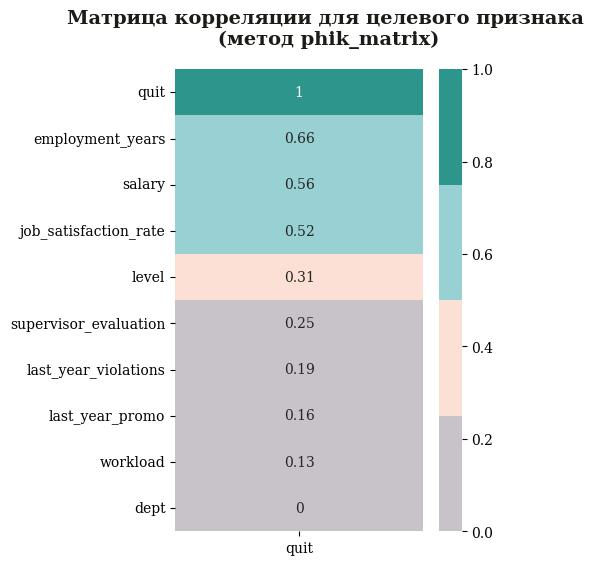

```python
fig = plt.figure(figsize=(4, 6))
fig.suptitle(f'Матрица корреляции для целевого признака\n (метод phik_matrix)', fontsize=14, fontweight='demi', color='#1B1B17')
ax1 = fig.add_subplot(1, 1, 1)
sns.heatmap(target_value_corr, ax=ax1, cmap=['#C8C3C9', '#FCE0D5', '#99D0D3', '#2E958C'], annot=True)

plt.show()
# построение тепловой карты корреляций для целевого признака
```

Целевая переменная `quit` имеет **среднюю** корреляцию с 3 числовыми признаками:

- `employment_years` - *0.66*,
- `salary` - *0.56*,
- `job_satisfaction_rate` - *0.52*.

Среди категориальных переменных слабая корреляция *(0.31)* с целевым параметром присутствует у признака `level`.

Для уволенных сотрудников корреляция между зарплатой `salary` и количеством лет в компании `employment_years` **сильнее**, чем для оставшихся.

Взаимосвязи отдела `dept`, в котором работает сотрудник, с увольнением `quit` не наблюдается. Можно будет попробовать **удалить** этот признак как малозначимый и не использовать в построении моделей.

### Вывод:

Целевой признак `quit` показал только **среднюю** корреляцию корреляции с 3 переменными: `employment_years` - *0.66*, `salary` - *0.56*, `job_satisfaction_rate` - *0.52*.

## 10. Задача 2: Подготовка данных

```python
all_test_features_df = test_features_df.merge(test_target_satisfaction_df, on='id', how='left').merge(test_target_quit_df, on='id', how='left')
# объединяем тестовые признаки с таргетом
```

```python
len(set(all_test_features_df['id'].unique()).intersection(set(train_quit_df['id'].unique())))
# определяем пересечение двух множеств
```

```
0
```

```python
train_quit_df = train_quit_df.set_index('id')
all_test_features_df = all_test_features_df.set_index('id')
# переназначаем индексы
```

```python
num_columns = ['employment_years',
               'supervisor_evaluation',
               'salary',
               'job_satisfaction_rate']
ord_columns = ['level', 'workload']
ohe_columns = ['last_year_promo', 'last_year_violations']
# создаём списки с названиями признаков
```

```python
print(f'Количество явных дубликатов: {train_quit_df.duplicated(subset=list(train_quit_df.columns)).sum()} \n')
display(train_quit_df[train_quit_df.duplicated(subset=list(train_quit_df.columns))])
# вывод строк-дубликатов
```

```
Количество явных дубликатов: 1413
```

| id | dept | level | workload | employment_years | last_year_promo | last_year_violations | supervisor_evaluation | salary | quit | job_satisfaction_rate |
| --- | --- | --- | --- | --- | --- | --- | --- | --- | --- | --- |
| 873412 | technology | junior | medium | 2 | no | no | 4 | 31200 | no | 0.811111 |
| 749683 | sales | middle | low | 8 | no | no | 4 | 19200 | no | 0.668750 |
| 689526 | marketing | middle | low | 6 | no | no | 3 | 30000 | no | 0.438400 |
| 786443 | purchasing | middle | low | 6 | no | no | 4 | 19200 | no | 0.676667 |
| 362060 | sales | junior | low | 1 | no | no | 4 | 12000 | yes | 0.514167 |
| ... | ... | ... | ... | ... | ... | ... | ... | ... | ... | ... |
| 632886 | sales | junior | low | 3 | no | no | 4 | 12000 | no | 0.638333 |
| 387733 | marketing | middle | medium | 5 | no | no | 3 | 44400 | no | 0.438400 |
| 588809 | sales | junior | medium | 4 | no | no | 3 | 26400 | no | 0.528571 |
| 672059 | sales | middle | high | 9 | no | no | 4 | 52800 | no | 0.848889 |
| 853842 | sales | junior | medium | 2 | no | no | 3 | 27600 | yes | 0.522500 |

1413 rows × 10 columns

```python
train_quit_df_no_dupl = train_quit_df.drop_duplicates()
# удаление дубликатов
```

```python
print(f'Количество явных дубликатов: {train_quit_df_no_dupl.duplicated(subset=list(train_quit_df_no_dupl.columns)).sum()} \n')
```

```
Количество явных дубликатов: 0
```

```python
train_quit_df_no_dupl['quit'] = train_quit_df_no_dupl['quit'].apply(lambda x: 1 if x == 'yes' else 0)
all_test_features_df['quit'] = all_test_features_df['quit'].apply(lambda x: 1 if x == 'yes' else 0)
# переводим целевой признак в числовой бинарный
```

```python
train_quit_df_no_dupl = train_quit_df_no_dupl.drop(['dept'], axis=1)
all_test_features_df = all_test_features_df.drop(['dept'], axis=1)
# удаляем малозначимый признак dept
```

```python
X_train = train_quit_df_no_dupl.drop(['quit'], axis=1)
y_train = train_quit_df_no_dupl['quit']
X_test = all_test_features_df.drop(['quit'], axis=1)
y_test = all_test_features_df['quit']
# формирование X_train, y_train, X_test, y_test
```

```python
print(f'''Количество строк в тренировочной выборке: {X_train.shape[0]}
Количество признаков в тренировочной выборке: {X_train.shape[1]}''')
```

```
Количество строк в тренировочной выборке: 2587
Количество признаков в тренировочной выборке: 8
```

```python
print(f'''Количество строк в тренировочной выборке: {X_test.shape[0]}
Количество признаков в тренировочной выборке: {X_test.shape[1]}''')
```

```
Количество строк в тренировочной выборке: 2000
Количество признаков в тренировочной выборке: 8
```

## 11. Задача 2: Обучение моделей

```python
ohe_pipe = Pipeline(
    [('simpleImputer_ohe', SimpleImputer(missing_values=np.nan, strategy='most_frequent')),
     ('ohe', OneHotEncoder(drop='first', handle_unknown='ignore', sparse=False))
    ]
    )
# создаём пайплайн для подготовки признаков из списка ohe_columns: заполнение пропусков и OHE-кодирование
# SimpleImputer + OHE

ord_pipe = Pipeline(
    [('simpleImputer_before_ord', SimpleImputer(missing_values=np.nan, strategy='most_frequent')),
     ('ord',  OrdinalEncoder(categories=[['junior', 'middle', 'sinior'],
                                         ['low', 'medium', 'high']],
                             handle_unknown='use_encoded_value',
                             unknown_value=np.nan
                            )
        ),
     ('simpleImputer_after_ord', SimpleImputer(missing_values=np.nan, strategy='most_frequent'))
    ]
)
# создаём пайплайн для подготовки признаков из списка ord_columns: заполнение пропусков и Ordinal-кодирование
# SimpleImputer + OE

data_preprocessor = ColumnTransformer(
    [('ohe', ohe_pipe, ohe_columns),
     ('ord', ord_pipe, ord_columns),
     ('num', StandardScaler(), num_columns)
    ],
    remainder='passthrough'
)
# создаём общий пайплайн для подготовки данных - кодирования и масштабирования
```

```python
pipe_final = Pipeline([
    ('preprocessor', data_preprocessor),
    ('models', LogisticRegression(random_state=RANDOM_STATE))
])
# создаём итоговый пайплайн: подготовка данных и модель

param_grid = [
    {
        'models': [DecisionTreeClassifier(random_state=RANDOM_STATE)],
        'models__max_depth': range(3, 10),
        'models__max_features': range(3, 10),
        'preprocessor__num': [StandardScaler(), MinMaxScaler(), RobustScaler(), 'passthrough']
    },
    # словарь для модели DecisionTreeClassifier()

    {
        'models': [KNeighborsClassifier()],
        'models__n_neighbors': range(7, 15),
        'preprocessor__num': [StandardScaler(), MinMaxScaler(), RobustScaler(), 'passthrough']
    },
    # словарь для модели KNeighborsClassifier()

    {
        'models': [LogisticRegression(
            random_state=RANDOM_STATE
        )],
        'models__C': [0.1, 1.0, 10.0, 100],
        'models__solver': ['liblinear', 'saga'],
        'models__penalty': [None, 'l1'],
        'preprocessor__num': [StandardScaler(), MinMaxScaler(), RobustScaler(), 'passthrough']
    },
    # словарь для модели LogisticRegression()

    {
        'models': [SVC(random_state=RANDOM_STATE)],
        'models__kernel': ['poly', 'rbf'],
        'models__degree': range(2, 10),
        'preprocessor__num': [StandardScaler(), MinMaxScaler(), RobustScaler(), 'passthrough']
    }
    # словарь для модели SVC()
]
```

```python
randomized_search = RandomizedSearchCV(
    pipe_final,
    param_grid,
    cv=5,
    scoring='roc_auc',
    random_state=RANDOM_STATE,
    n_jobs=-1
)
# запуск поиска гиперпараметров с помощью RandomizedSearchCV

randomized_search.fit(X_train, y_train)
# обучение модели

print('Лучшая модель и её параметры:\n\n', randomized_search.best_estimator_)
print ('Метрика лучшей модели на кросс валидационной выборке:', round(randomized_search.best_score_, 3))
```

```
Лучшая модель и её параметры:

 Pipeline(steps=[('preprocessor',
                 ColumnTransformer(remainder='passthrough',
                                   transformers=[('ohe',
                                                  Pipeline(steps=[('simpleImputer_ohe',
                                                                   SimpleImputer(strategy='most_frequent')),
                                                                  ('ohe',
                                                                   OneHotEncoder(drop='first',
                                                                                 handle_unknown='ignore',
                                                                                 sparse=False))]),
                                                  ['last_year_promo',
                                                   'last_year_violations']),
                                                 ('ord',
                                                  Pipeline(steps=[('simpleImputer_before_ord',
                                                                   SimpleI...
                                                                                              ['low',
                                                                                               'medium',
                                                                                               'high']],
                                                                                  handle_unknown='use_encoded_value',
                                                                                  unknown_value=nan)),
                                                                  ('simpleImputer_after_ord',
                                                                   SimpleImputer(strategy='most_frequent'))]),
                                                  ['level', 'workload']),
                                                 ('num', RobustScaler(),
                                                  ['employment_years',
                                                   'supervisor_evaluation',
                                                   'salary',
                                                   'job_satisfaction_rate'])])),
                ('models',
                 DecisionTreeClassifier(max_depth=4, max_features=6,
                                        random_state=42))])
Метрика лучшей модели на кросс валидационной выборке: 0.905
```

```python
y_test_prob = randomized_search.predict_proba(X_test)
y_test_pred = randomized_search.predict(X_test)
print(f'Метрика ROC-AUC на тестовой выборке: {round(roc_auc_score(y_test, y_test_prob[:, 1]), 3)}')
print(f'Метрика F1 на тестовой выборке: {round(f1_score(y_test, y_test_pred), 3)}')
# рассчитаем прогноз на тестовых данных и оценим точность
```

```
Метрика ROC-AUC на тестовой выборке: 0.915
Метрика F1 на тестовой выборке: 0.798
```

### Вывод:

Лучшей моделью для предсказания вероятности увольнения сотрудников оказалась модель "Дерево решений" - **DecisionTreeClassifier(max_depth=4, max_features=6, random_state=42)**. Метрика *ROC_AUC* качества классификации для кросс валидационной выборки - **0.905**. На тестовых данных - **0.915**. Это соответсвует критерию успеха для тестовых данных: *ROC_AUC >= 0.91*.

## Общий вывод

- На начальном этапе была проведена предобработка данных. Полные дубликаты и некорректные типы данных не были найдены. Мы обнаружили пропуски и пробелы в признаках `debt`, `workload` и `level`, которые потом заполнили в пайплайне и заменили на самые распространённые значения.
- В ходе исследовательского анализа данных для обеих задач были рассмотрены все числовые и категориальные признаки. С помощью гистограмм и статистических тестов мы оценили характер распределенний, а по диаграммам размаха определили медианные значения параметров и проверили наличие выбросов. Анализ категориальных переменных показал, что преобладают сотрудники из отдела продаж, джуны со средним уровнем загруженности.

Во 2 задаче мы дополнительно изучили уволившихся сотрудников.

Уволенные сотрудники в среднем проработали в компании меньше лет, чем оставшиеся. Большинство - всего 1-2 года. Их медианная оценка качества работы от начальства (3) на балл меньше оценки оставшихся сотрудников. Средняя зарплата уволенных также была на порядок меньше - 22 800. Среди уволенных по отделам самый большой процент 29.7% наблюдается у технологического. На последнем месте hr отдел. Там было уволено 25%. Уволенных джунов - 51%, а 6.4 и 4.8% приходится на мидлов и сеньоров соответственно. Интересно, что по уровню загруженности самая большая доля уволенных 43% у мало загруженных. (30%) из тех, кто не получал повышения за прошлый год, были уволены и всего 0.9% из тех, кто повышение получил. У нарушивших трудовой договор сотрудников доля уволенных составляет 42%, у добросовестных - 26%.

- На этапе корреляционного анализа мы построили матрицы корреляций. Мультиколлинеарность между признаками не была обнаружена.

В 1 задаче у целевой переменной `job_satisfaction_rate` имеется сильная корреляция с числовым признаком `supervisor_evaluation` (0.73 phik) и средняя с категориальным - `last_year_violations` (0.59 phik).

Во 2 задаче целевая переменная `quit` имеет среднюю корреляцию с 3 числовыми признаками: `employment_years` - 0.66, `salary` - 0.56, `job_satisfaction_rate` - 0.52. Для уволенных сотрудников корреляция между зарплатой `salary` и количеством лет в компании `employment_years` сильнее, чем для оставшихся.

- Для построения моделей мы использовали общий пайплайн и инструмент для подбора гиперпараметров - RandomizedSearchCV. На этапе подготовки признаков числовые параметры были приведены к единой шкале, категориальные признаки были закодированы.

В 1 задаче лучшей моделью для предсказания уровня удовлетворённости сотрудников оказалась модель "Дерево решений" - DecisionTreeRegressor(max_depth=13, max_features=19, random_state=42). Метрика SMAPE качества для кросс валидационной выборки - 15.768. На тестовых данных - 14.383. Это соответсвует критерию успеха для тестовых данных: SMAPE <= 15.

Во 2 задаче лучшей моделью для предсказания вероятности увольнения сотрудников оказалась модель "Дерево решений" - DecisionTreeClassifier(max_depth=4, max_features=6, random_state=42). Метрика ROC_AUC качества классификации для кросс валидационной выборки - 0.905. На тестовых данных - 0.915. Это соответсвует критерию успеха для тестовых данных: ROC_AUC >= 0.91.

Предсказание оттока — одна из важнейших задач HR-аналитиков. Внезапные увольнения несут в себе риски для компании, особенно если уходит важный сотрудник, поэтому на основе проведённого анализа мы можем дать бизнесу следующие рекомендации:

- Пересмотрель условия трудового договора.

В нашей выборке 14% сотрудников нарушали трудовой договор только лишь за последний год. Из них доля уволенных - 42%. Это сигнал работодателю. Возможно сотрудников не устраивает трудовой распорядок или они не исполняют свои обязанности в полном объёме из-за отсутвия перспектив и стимулов. Специалисты, которые чувствуют, что их карьера начала переходить в состояние стагнации, с большей вероятностью будут тормозить рабочий процесс.

- Чаще выражать признательность и показывать сотрудникам имеющиеся возможности для роста.

Оценка сотрудниками уровня удовлетворённости работой связана от части с тем, как их работу оценивает руководитель. Частые положительные отзывы за хорошо выполненную работу является мощным инструментом сохранения ключевых специалистов в любой обстановке.

- Изменить критерии для принятия решения о повышении сотрудника.

По результатам нашего исследования за год повышение получили только 3% сотрудников, а 30% из тех, кто не получал повышения за прошлый год, ушли из компании. Отток сотрудников может происходить, если их не устраивает уровень заработной платы. Многие проработав 1-2 года в компании рассчитывают получить повышение, но в итоге уходят, если их ожидания не оправдались.

- Разработать меры по удержанию технических специалистов.

Сотрудники технического отдела - одни из ключевых специаластов в компании. Данный отдел не самый крупный по численности сотрудников в нашей компании, однако, там наблюдается большой процент уволенных 29.7%.